# Mathematics of Sphere Packing

The sphere packing problem is a classical optimization problem that asks for the densest arrangement of non-overlapping spheres in a given space. The problem has a wide range of applications in various fields, including coding theory, cryptography, and wireless communication. The previous [post](https://csuraparaju.github.io/posts/noisy-channel/noiseIndex.html) discusses a concrete application. In this post, we will build up the mathematical machinery to understand the problem and come up with a randomized algorithm that achieves trivial lower bounds on the density of the packing.

# Definitions and Problem

Let $d$ be fixed and consider $\mathbb{R}^d$. A set of points $\mathcal{P} \subseteq \mathbb{R}^d$ is a sphere packing iff $\forall x \neq y \in \mathcal{P}, ||x - y||_2 \geq 2r_d$, where $r_d$ is the radius of sphere with volume 1 in $d$ dimensions. So, $\mathcal{P}$ represents the centers of all the spheres in the packing.

Define the quantity $$\theta(d) = \sup_{\mathcal{P} \subseteq \mathbb{R}^d} \limsup_{L \to \infty} \frac{|\mathcal{P} \cap [-L, L]^d|}{(2L)^d}$$ where $[-L, L]^d$ is the $d$-dimensional cube of with length $2L$.

[figure not shown]

Two sphere packings of different radii when d = 3. The one on the left has a lower density than the one on the right.

It can be shown that we can swap the supremum and the limit in the definition of $\theta(d)$, and so we will be fixing an arbitrary cube $[-L, L]^d$ and maximizing the density of a packing $\mathcal{P} \subset [-L, L]^d$.

# The Trivial Lower Bound

However, it is not known what the exact value of $\theta(d)$ is, and recent advancements have only been able to find the answer for $d = 1, 2, 3, 4, 8, 24$. So, we will instead focus on a trivial lower bound on $\theta(d)$ and try to find an algorithm for generating a packing that achieves this lower bound. Let $\mathcal{P}$ be a sphere packing that is maximal, i.e, adding another point $x$ into $\mathcal{P}$ will cause $x$ to be within distance $2r_d$ of some other point in $\mathcal{P}$. Consider a point $y \in [-L, L]^d$. We know that $\exists x \in \mathcal{P}$ such that $||x-y||_2 \leq 2r_d$ (otherwise, we could add $y$ to $\mathcal{P}$ and the packing is not maximal). But then, we know that $y \in B(x, 2r_d)$, where $B(x, 2r_d)$ is the ball centered at $x$ with radius $2r_d$. Since $y$ was arbitrary, observe that $\cup_{x \in \mathcal{P}} B(x, 2r_d)$ covers the entire cube $[-L, L]^d$. So, since the cube has volume $(2L)^d$, we can conclude $$ (2L)^d \leq \sum_{x \in \mathcal{P}} \text{vol}(B(x, 2r_d)) \leq 2^d \cdot |\mathcal{P}| $$ where the last step follows because $r_d$ was chosen such that the volume of a ball of radius $r_d$ is 1, so $\text{vol}(B(x, 2r_d)) = 2^d$. Rearranging, we see that $\frac{|\mathcal{P}|}{(2L)^d} \geq \frac{1}{2^d}$, and because $\mathcal{P}^d \subset [-L, L]^d$ we have that $\theta(d) \geq \frac{1}{2^d}$. But how can we actually generate a packing that achieves this lower bound?

# Connections to Graph Theory

A breakthrough insight made my mathematicians was to recognize the connection between this problem and graph theory. Consider the following graph $G = (V, E)$ where $V \subseteq X \subseteq [-L, L]^d$ and $E = \{(x, y) \in V \times V \mid ||x-y||_2 < 2r_d\}$. Define an independent set in $G$ to be a set of vertices $I \subseteq V$ such that $(x, y) \notin E$ for all $x, y \in I$. Now, note that an independent set in $G$ corresponds to a sphere packing because if $(x, y) \not\in E$, then $||x-y||_2 \geq 2r_d$. So, the sphere packing problem is equivalent to finding the largest independent set in $G$. So now, we can rewrite $\theta(d)$ as $$ \theta(d) = \frac{\alpha(G)}{(2L)^d} $$ where $\alpha(G)$ is the size of the largest independent set in $G$.

[figure not shown]

An example of a graph G and its largest independent set I.

Before we proceed further, note that for $G$ to exist, we need to find an $X$ that is finite. To do this, we will generate a set of random points in $[-L, L]^d$ such that $X$ is a realization of a poisson point process with intensity $\lambda$. This means that the expected number of points in $X$ is $\lambda \cdot \text{vol}([-L, L]^d) = \lambda \cdot (2L)^d$, and so $|X| \sim Po(\lambda \cdot (2L)^d)$.

# Randomized Algorithm

An important result in graph theory is Turán's theorem, which states that for a graph $G$ with $\Delta$ such that $d(G) \geq \Delta$, then $\alpha(G) \geq \frac{|V|}{\Delta + 1}$, where $d(G)$ is the maximum degree of all vertices in $G$. We will use this theorem to come up with a randomized algorithm that achieves the trivial lower bound on $\theta(d)$. The algorithm is as follows:

1. Generate a realization of a poisson point process with large enough $\lambda$ in $[-L, L]^d$.
2. Construct the graph $G$ as described above, and choose $\Delta = \lambda \cdot 2^d$.
3. If $d(G) \geq \Delta$, then remove all vertices with degree greater than $\Delta$.
4. Find the largest independent set $I$ in the resulting graph (Note that this is an NP-hard problem, but runtime is for another post ...)
5. Return $I$ as $\mathcal{P}$.

If we can show that the deletion step, in expectation, does not remove too many points, then we can argue that the algorithm achieves the trivial lower bound on $\theta(d)$. By Turán's theorem, the size of the largest independent set in the graph outputted by the algorithm $\alpha(G) \geq \frac{|V|}{\Delta + 1},$ which in expectation is equal to $\frac{|X|}{\Delta + 1} = \frac{\lambda \cdot (2L)^d}{\lambda \cdot 2^d + 1} \geq \frac{(2L)^2}{2^d + 1} \geq \frac{(2L)^d}{2^d}$. Plugging this value in for $\alpha(G)$, we see that $\theta(d) \geq \frac{1}{2^d}$, achieving the trivial lower bound.

To see that the deletion step does not remove too many points, we can find the probability that a point $x \in X$ has degree greater than $\Delta$. This happens when $x$ is within distance $2r_d$ of more than $\Delta$ other points in $X$. Since $X$ is a realization of a poisson point process, the number of points in $X$ within distance $2r_d$ of $x$ is a poisson random variable with mean $\lambda \cdot \text{vol}(B(x, 2r_d)) = \lambda \cdot 2^d$. So, the probability that $x$ has degree greater than $\Delta$ is $$P(X \geq \Delta) = 1 - P(X < \Delta) = 1 - \sum_{i=0}^{\Delta - 1} \frac{e^{-\lambda \cdot 2^d} \cdot (\lambda \cdot 2^d)^i}{i!}$$

We can show that this probability is small for large enough $\lambda$ and $d$, and so the deletion step does not remove too many points in expectation.

# Implementation

We will now implement the algorithm in Python and visualize the sphere packing generated by the algorithm.

```python
import numpy as np
import math
import matplotlib.pyplot as plt
import networkx as nx
from networkx.algorithms import approximation as approx
from scipy.spatial import distance_matrix

class SpherePacking:
    def __init__(self, lambda_, L, d, r_d):
        self.lambda_ = lambda_
        self.L = L
        self.d = d
        self.r_d = r_d
        self.points = None

    def generate_poisson_points(self):
        num_points = np.random.poisson(self.lambda_ * (2 * self.L) ** self.d)
        return np.random.uniform(-self.L, self.L, size=(num_points, self.d))

    def construct_graph(self, points):
        distances = distance_matrix(points, points)
        adj_mat = (distances < 2 * self.r_d) & (distances > 0)
        return adj_mat

    def independent_set(self, adjacency_matrix):
        G = nx.Graph()
        num_vertices = adjacency_matrix.shape[0]
        G.add_nodes_from(range(num_vertices))
        for i in range(num_vertices):
            for j in range(i + 1, num_vertices):
                if adjacency_matrix[i, j]:
                    G.add_edge(i, j)
        return approx.maximum_independent_set(G)

    def pack(self):
        points = self.generate_poisson_points()
        adjacency_matrix = self.construct_graph(points)

        max_degree = int(self.lambda_ * (2 ** self.d))

        # Remove vertices whose degree is greater than max_degree
        degrees = adjacency_matrix.sum(axis=1)
        high_degree_mask = degrees > max_degree
        points = points[~high_degree_mask]
        adjacency_matrix = self.construct_graph(points)

        self.points = points[list(self.independent_set(adjacency_matrix))]

    def plot(self):
        fig = plt.figure()
        if self.d == 2:
            ax = fig.add_subplot(111)
            ax.set_xlim(-self.L, self.L)
            ax.set_ylim(-self.L, self.L)
            for point in self.points:
                circle = plt.Circle(point, self.r_d, color='red', alpha=0.3)
                ax.add_artist(circle)
            ax.scatter(self.points[:, 0], self.points[:, 1], color='blue', label='Circle Centers', s=2)
        elif self.d == 3:
            from mpl_toolkits.mplot3d import Axes3D
            ax = fig.add_subplot(111, projection='3d')
            ax.set_xlim(-self.L, self.L)
            ax.set_ylim(-self.L, self.L)
            ax.set_zlim(-self.L, self.L)
            ax.scatter(self.points[:, 0], self.points[:, 1], self.points[:, 2], color='blue', label='Sphere Centers', s=2)
            for point in self.points:
                u = np.linspace(0, 2 * np.pi, 20)
                v = np.linspace(0, np.pi, 20)
                x = self.r_d * np.outer(np.cos(u), np.sin(v)) + point[0]
                y = self.r_d * np.outer(np.sin(u), np.sin(v)) + point[1]
                z = self.r_d * np.outer(np.ones_like(u), np.cos(v)) + point[2]
                ax.plot_surface(x, y, z, color='red', alpha=0.3, edgecolor='none')
        else:
            raise ValueError("Cannot plot more than 3 dimensions")

        plt.legend()
        plt.show()
```

Let's visualize the 2D case first of the algorithm.

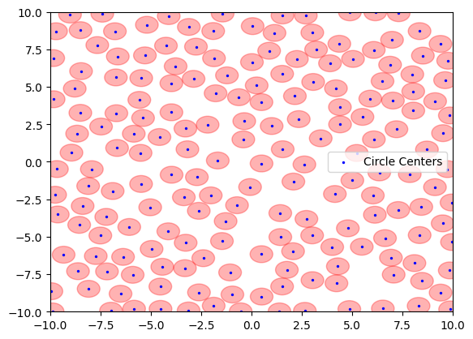

```python
lambda_ = 10 # (For a denser packing, increase lambda_, but computation time will increase as well)
L = 10 # Length of the cube
d = 2 # Dimension of the space
r_d = math.gamma(d / 2 + 1) / (math.pi ** (d / 2)) ** (1 / d)  # Radius of the sphere with volume 1

sp_2d = SpherePacking(lambda_, L, d, r_d)
sp_2d.pack()
sp_2d.plot()
```

Now, let's plot the 3D case of the algorithm (with smaller $\lambda$ for computational reasons).

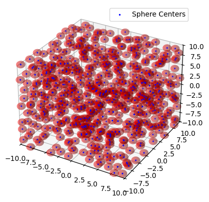

```python
lambda_ = 1
L = 10
d = 3
r_d = math.gamma(d / 2 + 1) / (math.pi ** (d / 2)) ** (1 / d)

sp_3d = SpherePacking(lambda_, L, d, r_d)
sp_3d.pack()
sp_3d.plot()
```